# 1. Preparation

#### First, we install the required packages.

- specify the settings that work for your coding environment)
- these packages are already installed if you are using the binder server

```r
# install.packages('network', .libPaths(), repos='http://cran.us.r-project.org')
# install.packages('ergm', .libPaths(), repos='http://cran.us.r-project.org')
# install.packages('devtools', .libPaths(), repos='http://cran.us.r-project.org')
```

#### We have a [workshop package](https://github.com/tedhchen/ergmWorkshopTools) that contains the data we will be working with and some utility functions.

```r
devtools::install_github('tedhchen/ergmWorkshopTools')
```

#### Next, we load the libraries.

```r
library(ergm)
library(ergmWorkshopTools)
```

# 2. Building our networks

#### First, load the data.

The data sets we will be using are part of the workshop package. We start with the militarized interstate dispute data from Zeev Maoz.

```r
data(mid_mat)
?mid_mat
```

`checkmat()` is a utility function that plots the supplied adjacency matrix.

**Note about plotting:** You can ignore the plotting `options` if you are not using a jupyter notebook.

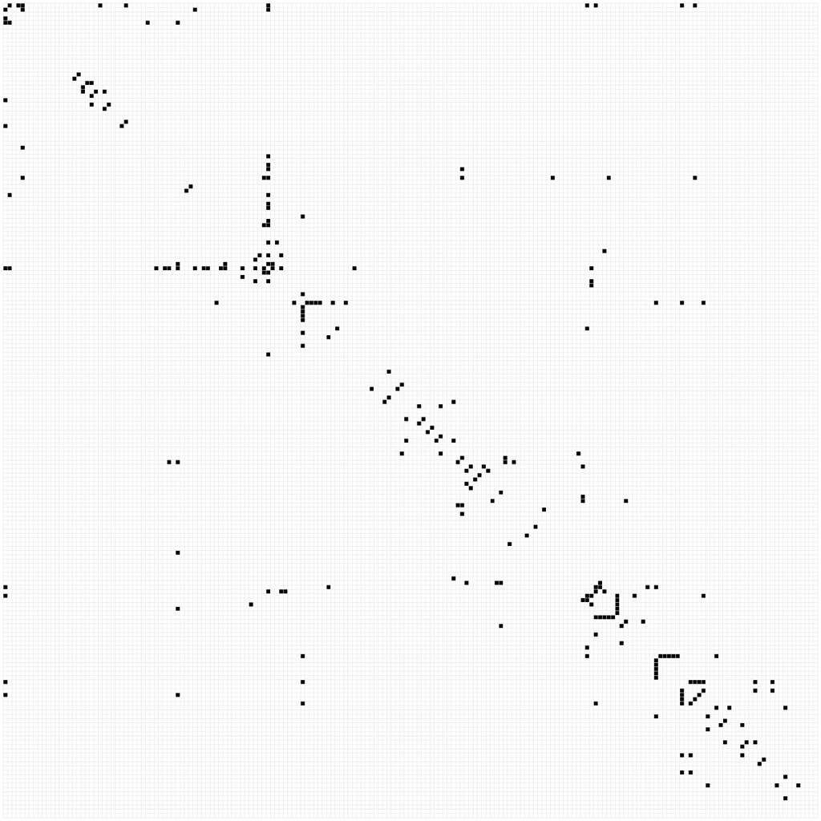

```r
options(repr.plot.width=10, repr.plot.height=10)
checkmat(mid_mat)
```

#### Next, we use the `network` function to create a network object.

```r
?network
```

```r
nw <- network(mid_mat, directed = F)
nw
```

```
 Network attributes:
  vertices = 189
  directed = FALSE
  hyper = FALSE
  loops = FALSE
  multiple = FALSE
  bipartite = FALSE
  total edges= 134
    missing edges= 0
    non-missing edges= 134

 Vertex attribute names:
    vertex.names

No edge attributes
```

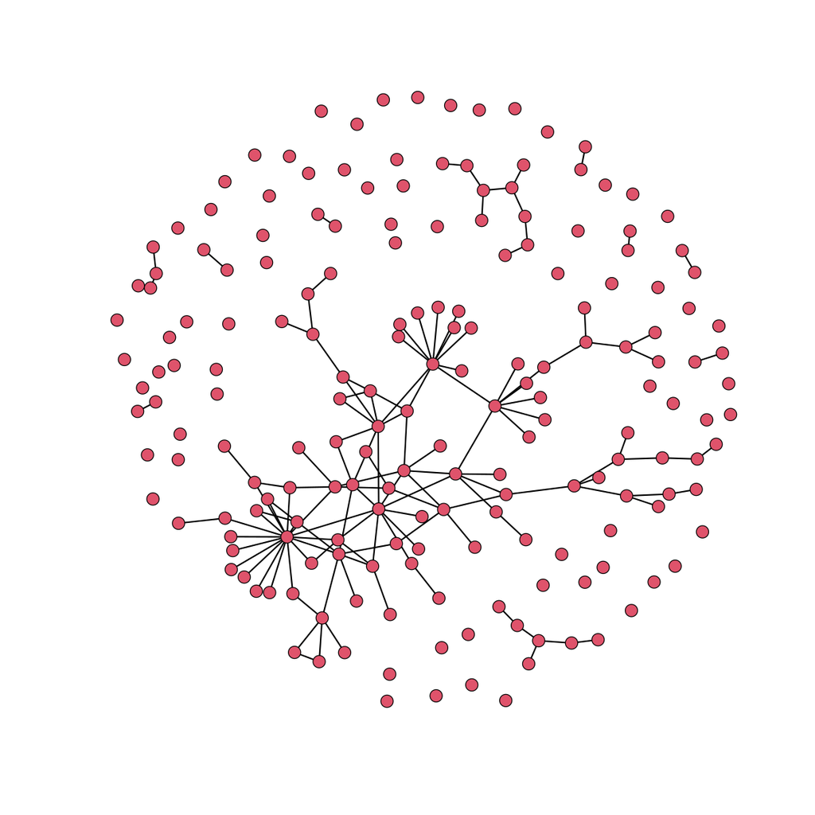

```r
options(repr.plot.width=10, repr.plot.height=10)
par(mfrow = c(1, 1))
set.seed(210615); plot(nw)
```

#### There are different ways network data is usually stored.

The adjacency matrix format is generally the easiest to work with, but it can take a lot of space.

Sometimes, we will have edgelists instead. In fact, unless you have pre-prepared network data, edgelists are usually what you'll have.

#### We need to be careful when working with them.

```r
data(mid_edgelist)
nw.b <- network(mid_edgelist, directed = F)
nw.b
```

```
 Network attributes:
  vertices = 120
  directed = FALSE
  hyper = FALSE
  loops = FALSE
  multiple = FALSE
  bipartite = FALSE
  total edges= 134
    missing edges= 0
    non-missing edges= 134

 Vertex attribute names:
    vertex.names

No edge attributes
```

#### What's the difference?

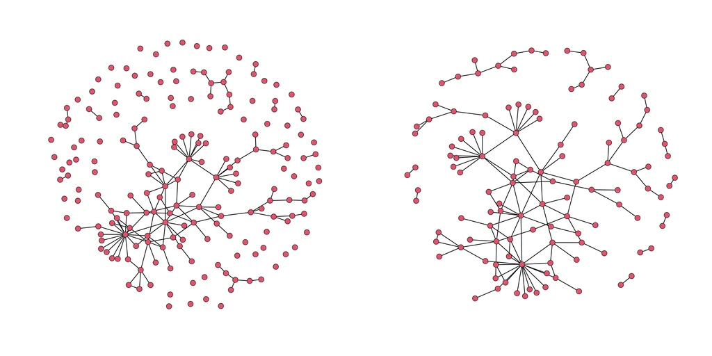

```r
options(repr.plot.width=20, repr.plot.height=10)
par(mfrow = c(1, 2))
set.seed(210615); plot(nw); plot(nw.b)
```

#### Where are the isolates?

The edgelist does not contain information about them.

#### When working with this kind of data, we have to make sure we have a list of the full actors in the network.

```r
data(mid_node_attr)
head(mid_node_attr)
?mid_node_attr
```

A data.frame: 6 × 5

|  | name <chr> | intrastate <dbl> | dem <dbl> | cinc <dbl> | trans <dbl> |
| --- | --- | --- | --- | --- | --- |
| 2 | USA | 0 | 1 | 0.149933 | 0 |
| 20 | CAN | 0 | 1 | 0.012238 | 0 |
| 31 | BHM | 0 | 1 | 0.000044 | 0 |
| 40 | CUB | 1 | 0 | 0.002783 | 0 |
| 41 | HAI | 1 | 0 | 0.000443 | 0 |
| 42 | DOM | 0 | 0 | 0.000748 | 0 |

#### Let's manually make the adjacency matrix from the edgelist.

- Start by making an empty matrix.

```r
mat <- matrix(0, ncol = 189, nrow = 189, dimnames = list(row.names(mid_node_attr), row.names(mid_node_attr)))
mat[1:10, 1:10]
```

A matrix: 10 × 10 of type dbl

|  | 2 | 20 | 31 | 40 | 41 | 42 | 51 | 52 | 53 | 54 |
| --- | --- | --- | --- | --- | --- | --- | --- | --- | --- | --- |
| 2 | 0 | 0 | 0 | 0 | 0 | 0 | 0 | 0 | 0 | 0 |
| 20 | 0 | 0 | 0 | 0 | 0 | 0 | 0 | 0 | 0 | 0 |
| 31 | 0 | 0 | 0 | 0 | 0 | 0 | 0 | 0 | 0 | 0 |
| 40 | 0 | 0 | 0 | 0 | 0 | 0 | 0 | 0 | 0 | 0 |
| 41 | 0 | 0 | 0 | 0 | 0 | 0 | 0 | 0 | 0 | 0 |
| 42 | 0 | 0 | 0 | 0 | 0 | 0 | 0 | 0 | 0 | 0 |
| 51 | 0 | 0 | 0 | 0 | 0 | 0 | 0 | 0 | 0 | 0 |
| 52 | 0 | 0 | 0 | 0 | 0 | 0 | 0 | 0 | 0 | 0 |
| 53 | 0 | 0 | 0 | 0 | 0 | 0 | 0 | 0 | 0 | 0 |
| 54 | 0 | 0 | 0 | 0 | 0 | 0 | 0 | 0 | 0 | 0 |

- Next, loop through the edgelist and fill the correct cells.

```r
for(i in 1:nrow(mid_edgelist)){
    mat[mid_edgelist[i, 1], mid_edgelist[i, 2]] <- 1
    mat[mid_edgelist[i, 2], mid_edgelist[i, 1]] <- 1
}
```

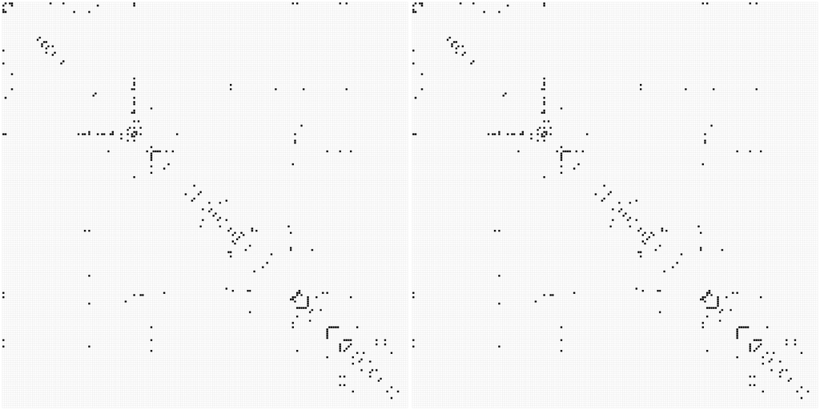

```r
options(repr.plot.width=14, repr.plot.height=7)
par(mfrow = c(1, 2))
checkmat(mat);checkmat(mid_mat)
```

#### Let's get back to working with our network.

```r
nw
```

```
 Network attributes:
  vertices = 189
  directed = FALSE
  hyper = FALSE
  loops = FALSE
  multiple = FALSE
  bipartite = FALSE
  total edges= 134
    missing edges= 0
    non-missing edges= 134

 Vertex attribute names:
    vertex.names

No edge attributes
```

#### Let's work with vertex attributes.

The `%v%` operator is how to access vertex/node variables from the network object.

```r
nw%v%'vertex.names'
```

1. '2'

2. '20'

3. '31'

4. '40'

5. '41'

6. '42'

7. '51'

8. '52'

9. '53'

10. '54'

11. '55'

12. '56'

13. '57'

14. '58'

15. '60'

16. '70'

17. '80'

18. '90'

19. '91'

20. '92'

21. '93'

22. '94'

23. '95'

24. '100'

25. '101'

26. '110'

27. '115'

28. '130'

29. '135'

30. '140'

31. '145'

32. '150'

33. '155'

34. '160'

35. '165'

36. '200'

37. '205'

38. '210'

39. '211'

40. '212'

41. '220'

42. '221'

43. '223'

44. '225'

45. '230'

46. '232'

47. '235'

48. '255'

49. '265'

50. '290'

51. '305'

52. '310'

53. '315'

54. '316'

55. '317'

56. '325'

57. '331'

58. '338'

59. '339'

60. '343'

61. '344'

62. '345'

63. '346'

64. '349'

65. '350'

66. '352'

67. '355'

68. '359'

69. '360'

70. '365'

71. '366'

72. '367'

73. '368'

74. '369'

75. '370'

76. '371'

77. '372'

78. '373'

79. '375'

80. '380'

81. '385'

82. '390'

83. '395'

84. '402'

85. '403'

86. '404'

87. '411'

88. '420'

89. '432'

90. '433'

91. '434'

92. '435'

93. '436'

94. '437'

95. '438'

96. '439'

97. '450'

98. '451'

99. '452'

100. '461'

101. '471'

102. '475'

103. '481'

104. '482'

105. '483'

106. '484'

107. '490'

108. '500'

109. '501'

110. '510'

111. '516'

112. '517'

113. '520'

114. '522'

115. '530'

116. '531'

117. '540'

118. '541'

119. '551'

120. '552'

121. '553'

122. '560'

123. '565'

124. '570'

125. '571'

126. '572'

127. '580'

128. '581'

129. '590'

130. '591'

131. '600'

132. '615'

133. '616'

134. '620'

135. '625'

136. '630'

137. '640'

138. '645'

139. '651'

140. '652'

141. '660'

142. '663'

143. '666'

144. '670'

145. '679'

146. '680'

147. '690'

148. '692'

149. '694'

150. '696'

151. '698'

152. '700'

153. '701'

154. '702'

155. '703'

156. '704'

157. '705'

158. '710'

159. '712'

160. '713'

161. '731'

162. '732'

163. '740'

164. '750'

165. '760'

166. '770'

167. '771'

168. '775'

169. '780'

170. '781'

171. '790'

172. '800'

173. '811'

174. '812'

175. '816'

176. '820'

177. '830'

178. '835'

179. '840'

180. '850'

181. '900'

182. '910'

183. '920'

184. '935'

185. '940'

186. '950'

187. '983'

188. '986'

189. '987'

#### We can look at how democracies and nondemocracies differ in conflict behavior.

```r
nw%v%'dem' <- mid_node_attr$'dem'
nw
```

```
 Network attributes:
  vertices = 189
  directed = FALSE
  hyper = FALSE
  loops = FALSE
  multiple = FALSE
  bipartite = FALSE
  total edges= 134
    missing edges= 0
    non-missing edges= 134

 Vertex attribute names:
    dem vertex.names

No edge attributes
```

```r
nw%v%'dem'
```

1. 1

2. 1

3. 1

4. 0

5. 0

6. 0

7. 1

8. 1

9. 1

10. 1

11. 1

12. 1

13. 1

14. 1

15. 1

16. 0

17. 1

18. 0

19. 1

20. 1

21. 0

22. 1

23. 1

24. 1

25. 1

26. 0

27. 0

28. 1

29. 0

30. 1

31. 1

32. 0

33. 1

34. 1

35. 1

36. 1

37. 1

38. 1

39. 1

40. 1

41. 1

42. 0

43. 1

44. 1

45. 1

46. 1

47. 1

48. 1

49. 0

50. 0

51. 1

52. 0

53. 0

54. 1

55. 1

56. 1

57. 1

58. 1

59. 0

60. 1

61. 0

62. 0

63. 0

64. 1

65. 1

66. 1

67. 0

68. 0

69. 0

70. 0

71. 1

72. 1

73. 1

74. 1

75. 0

76. 0

77. 0

78. 0

79. 1

80. 1

81. 1

82. 1

83. 1

84. 0

85. 0

86. 0

87. 0

88. 0

89. 0

90. 0

91. 0

92. 0

93. 0

94. 0

95. 0

96. 0

97. 0

98. 0

99. 0

100. 0

101. 0

102. 0

103. 0

104. 0

105. 0

106. 0

107. 0

108. 0

109. 0

110. 0

111. 0

112. 0

113. 0

114. 0

115. 0

116. 0

117. 0

118. 0

119. 0

120. 0

121. 0

122. 0

123. 1

124. 0

125. 1

126. 0

127. 0

128. 0

129. 1

130. 0

131. 0

132. 0

133. 0

134. 0

135. 0

136. 0

137. 1

138. 0

139. 0

140. 0

141. 0

142. 0

143. 1

144. 0

145. 0

146. 0

147. 0

148. 0

149. 0

150. 0

151. 0

152. 0

153. 0

154. 0

155. 0

156. 0

157. 0

158. 0

159. 0

160. 0

161. 0

162. 1

163. 1

164. 1

165. 0

166. 1

167. 0

168. 0

169. 0

170. 0

171. 0

172. 0

173. 0

174. 0

175. 0

176. 0

177. 0

178. 0

179. 1

180. 0

181. 1

182. 1

183. 1

184. 1

185. 1

186. 0

187. 1

188. 1

189. 1

#### Red nodes are democracies and black are nondemocracies.

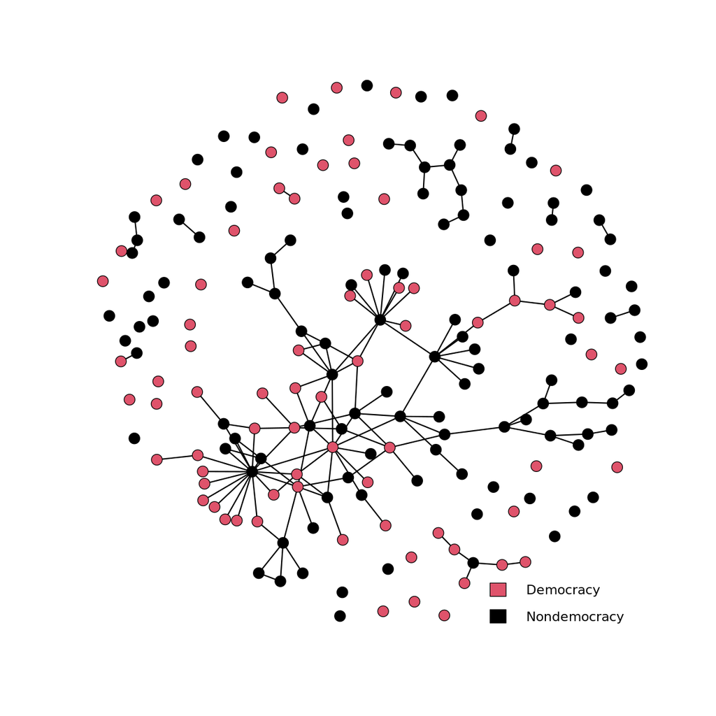

```r
options(repr.plot.width=10, repr.plot.height=10)
set.seed(210615); plot(nw, vertex.col = ifelse(nw%v%'dem', 2, 1)); legend('bottomright', legend = c('Democracy', 'Nondemocracy'), fill = c(2, 1), bty = 'n', cex = 1.1)
```

#### Edge attributes can also be specified in a similar way but it's easier to just use a separate matrix.

These are the geographical contiguity and joint-democracy networks.

```r
data(contig); data(joint_dem)
```

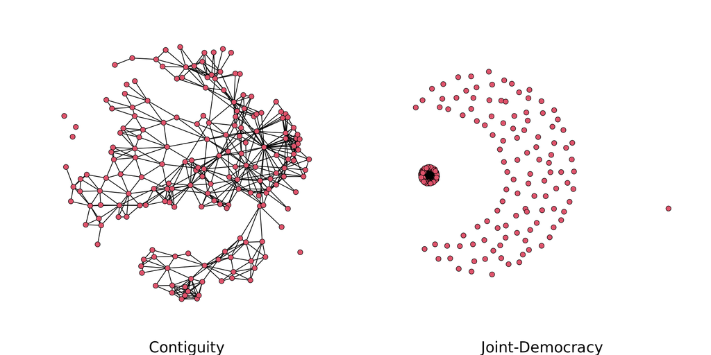

```r
options(repr.plot.width=16, repr.plot.height=8)
par(mfrow = c(1, 2))
set.seed(210615); plot(network(contig, directed = F), sub = 'Contiguity', cex.sub = 2); plot(network(joint_dem, directed = F), sub = 'Joint-Democracy', cex.sub = 2)
```

# 3. Specifying the ERGM

#### Let's take a look at the basic function for ERGM fitting: `ergm`.

> `ergm(network ~ ergm-terms)`

#### What are the ERGM terms that we can use?

## 3.1 ERGM Terms

- use `` ?`ergm-terms' `` to look at all the existing terms in the `ergm` package
- the `search.ergmTerms` function also works well

```r
?`ergm-terms`
```

```r
search.ergmTerms(keyword = 'transitive')
```

```
Found  15  matching ergm terms:
ddsp(d, type="OTP")


desp(d, type="OTP")


dgwdsp(decay, fixed=FALSE, cutoff=30, type="OTP")


dgwesp(decay, fixed=FALSE, cutoff=30, type="OTP")


dgwnsp(decay, fixed=FALSE, cutoff=30, type="OTP")


dnsp(d, type="OTP")


intransitive()
 Intransitive triads

intransitive()
 Intransitive triads

transitive()
 Transitive triads

transitiveties(attr=NULL, levels=NULL)
 Transitive ties

transitiveties(threshold=0)
 Transitive ties

transitiveweights(twopath="min",combine="max",affect="min")
 Transitive weights

triangle(attr=NULL, diff=FALSE, levels=NULL)
 Triangles

ttriple(attr=NULL, diff=FALSE, levels=NULL)
 Transitive triples

ttriad()
 Transitive triples
```

## 3.2 Starting to fit an ERGM

#### We start with some node and dyad variables.

- node-level democractic regime `nodefactor('dem')`
- joint-democracies `edgecov(joint_dem)`

```r
m0 <- ergm(nw ~ edges + nodefactor('dem') + edgecov(joint_dem))
summary(m0)
```

```
Starting maximum pseudolikelihood estimation (MPLE):

Evaluating the predictor and response matrix.

Maximizing the pseudolikelihood.

Finished MPLE.

Stopping at the initial estimate.

Evaluating log-likelihood at the estimate.
```

```
Call:
ergm(formula = nw ~ edges + nodefactor("dem") + edgecov(joint_dem))

Maximum Likelihood Results:

                  Estimate Std. Error MCMC % z value Pr(>|z|)
edges              -4.6678     0.1286      0 -36.287   <1e-04 ***
nodefactor.dem.1   -0.2632     0.1818      0  -1.447    0.148
edgecov.joint_dem  -0.2179     0.4078      0  -0.534    0.593
---
Signif. codes:  0 ‘***’ 0.001 ‘**’ 0.01 ‘*’ 0.05 ‘.’ 0.1 ‘ ’ 1

     Null Deviance: 24629  on 17766  degrees of freedom
 Residual Deviance:  1570  on 17763  degrees of freedom

AIC: 1576  BIC: 1599  (Smaller is better. MC Std. Err. = 0)
```

#### Let's compare it with the logistic regression.

```r
dyad_df <- ergmMPLE(nw ~ edges + nodefactor('dem') + edgecov(joint_dem))
dyad_df$predictor
```

A matrix: 6 × 3 of type dbl

| edges | nodefactor.dem.1 | edgecov.joint_dem |
| --- | --- | --- |
| 1 | 2 | 1 |
| 1 | 2 | 1 |
| 1 | 1 | 0 |
| 1 | 0 | 0 |
| 1 | 0 | 0 |
| 1 | 1 | 0 |

```r
summary(glm(dyad_df$response ~ dyad_df$predictor - 1, weights = dyad_df$weights, family = 'binomial'))
```

```
Call:
glm(formula = dyad_df$response ~ dyad_df$predictor - 1, family = "binomial",
    weights = dyad_df$weights)

Deviance Residuals:
      1        2        3        4        5        6
 11.402   -4.894   24.545   23.887  -11.020  -11.025

Coefficients:
                                   Estimate Std. Error z value Pr(>|z|)
dyad_df$predictoredges              -4.6678     0.1286 -36.287   <2e-16 ***
dyad_df$predictornodefactor.dem.1   -0.2632     0.1818  -1.447    0.148
dyad_df$predictoredgecov.joint_dem  -0.2179     0.4078  -0.534    0.593
---
Signif. codes:  0 ‘***’ 0.001 ‘**’ 0.01 ‘*’ 0.05 ‘.’ 0.1 ‘ ’ 1

(Dispersion parameter for binomial family taken to be 1)

    Null deviance: 24629  on 6  degrees of freedom
Residual deviance:  1570  on 3  degrees of freedom
AIC: 1576

Number of Fisher Scoring iterations: 7
```

#### They are exactly the same.

- when there are no network effects, the ERGM and a logistic regression is equivalent

#### Let's move to some network effects.

- start with the "pile-on" effect -`kstar(2)` (which is the 2-star term) is the basic term for this

```r
m1 <- ergm(nw ~ edges + nodefactor('dem') + edgecov(joint_dem) + kstar(2), control = control.ergm(seed = 210616))
```

```
Starting maximum pseudolikelihood estimation (MPLE):

Evaluating the predictor and response matrix.

Maximizing the pseudolikelihood.

Finished MPLE.

Starting Monte Carlo maximum likelihood estimation (MCMLE):

Iteration 1 of at most 60:
```

```
Error in ergm.MCMLE(init, nw, model, initialfit = (initialfit <- NULL), : Number of edges in a simulated network exceeds that in the observed by a factor of more than 20. This is a strong indicator of model degeneracy or a very poor starting parameter configuration. If you are reasonably certain tha…
Traceback:

1. ergm(nw ~ edges + nodefactor("dem") + edgecov(joint_dem) + kstar(2),
 .     control = control.ergm(seed = 210616))
2. ergm.MCMLE(init, nw, model, initialfit = (initialfit <- NULL),
 .     control = control, proposal = proposal, proposal.obs = proposal.obs,
 .     verbose = verbose, ...)
3. stop("Number of edges in a simulated network exceeds that in the observed by a factor of more than ",
 .     floor(control$MCMLE.density.guard), ". This is a strong indicator of model degeneracy or a very poor starting parameter configuration. If you are reasonably certain that neither of these is the case, increase the MCMLE.density.guard control.ergm() parameter.")
```

#### What happened here?

- This is one of the difficulties of ERGMs: they run into degeneracy issues.
- Degeneracy is a problem that arises during the simulation-based model estimation procedure.
- For simple model terms (e.g. 2-star), a single edge contribute to too many of the corresponding local configurations.
- We only end up simulating very dense or very sparse networks (i.e. the model is not a good representation of our network).

#### So instead, we can use alternative network statistics designed to address these problems.

- For the preferential attachment (or pile-on) effect, the commonly-used one is the geometrically-weighted degree.
- These kind of "geometrically weighted" terms are used to down-weigh the contribution of each edge to network configurations.
- In the `ergm` package, it is called `gwdegree`.

##### References:

Hunter, DR et al. 2008. ["ergm: A package to fit, simulate and diagnose exponentiall-family models for networks."](https://doi.org/10.18637/jss.v024.i03) *Journal of Statistical Software*.

Snijders, T et al. 2006. ["New specifications for exponential random graph models."](https://doi.org/10.1111/j.1467-9531.2006.00176.x) *Sociological Methodology*.

```r
m1 <- ergm(nw ~ edges + nodefactor('dem') + edgecov(joint_dem) + gwdegree(decay = 0, fixed = T), control = control.ergm(seed = 210616))
```

```
Starting maximum pseudolikelihood estimation (MPLE):

Evaluating the predictor and response matrix.

Maximizing the pseudolikelihood.

Finished MPLE.

Starting Monte Carlo maximum likelihood estimation (MCMLE):

Iteration 1 of at most 60:

Optimizing with step length 0.5407.

The log-likelihood improved by 1.6896.

Estimating equations are not within tolerance region.

Iteration 2 of at most 60:

Optimizing with step length 1.0000.

The log-likelihood improved by 0.4623.

Estimating equations are not within tolerance region.

Iteration 3 of at most 60:

Optimizing with step length 1.0000.

The log-likelihood improved by 0.1125.

Estimating equations are not within tolerance region.

Iteration 4 of at most 60:

Optimizing with step length 1.0000.

The log-likelihood improved by 0.0849.

```

[output cut: 38 more lines]

```
8
9
10
11
12
13
14
15
16
.

Bridging finished.

This model was fit using MCMC.  To examine model diagnostics and check
for degeneracy, use the mcmc.diagnostics() function.
```

#### Looks like it converged.

```r
summary(m1)
```

```
Call:
ergm(formula = nw ~ edges + nodefactor("dem") + edgecov(joint_dem) +
    gwdegree(decay = 0, fixed = T), control = control.ergm(seed = 210616))

Monte Carlo Maximum Likelihood Results:

                  Estimate Std. Error MCMC % z value Pr(>|z|)
edges              -4.1573     0.1528      0 -27.206   <1e-04 ***
nodefactor.dem.1   -0.1599     0.1738      0  -0.920    0.357
edgecov.joint_dem  -0.2259     0.3969      0  -0.569    0.569
gwdeg.fixed.0      -1.1605     0.2355      0  -4.928   <1e-04 ***
---
Signif. codes:  0 ‘***’ 0.001 ‘**’ 0.01 ‘*’ 0.05 ‘.’ 0.1 ‘ ’ 1

     Null Deviance: 24629  on 17766  degrees of freedom
 Residual Deviance:  1544  on 17762  degrees of freedom

AIC: 1552  BIC: 1583  (Smaller is better. MC Std. Err. = 0.4484)
```

- the `gwdeg.fixed.0` term has coefficient of -1.16
- **for the geometrically weighted degree term, negative means popular**
  - This is an easy mistake: a review in 2016 shows that only 4/16 papers got it right.
- compare the model fit statistics: AIC and BIC are both much better than without fitting the pile-on effect

#### Let's also add the triadic closure effect before looking at the model in more detail.

```r
m2 <- ergm(nw ~ edges + nodefactor('dem') + edgecov(joint_dem) + gwdegree(decay = 0, fixed = T) + triangle, control = control.ergm(seed = 210616))
```

```
Starting maximum pseudolikelihood estimation (MPLE):

Evaluating the predictor and response matrix.

Maximizing the pseudolikelihood.

Finished MPLE.

Starting Monte Carlo maximum likelihood estimation (MCMLE):

Iteration 1 of at most 60:

Optimizing with step length 0.3570.

The log-likelihood improved by 1.7058.

Estimating equations are not within tolerance region.

Iteration 2 of at most 60:
```

```
Error in ergm.MCMLE(init, nw, model, initialfit = (initialfit <- NULL), : Number of edges in a simulated network exceeds that in the observed by a factor of more than 20. This is a strong indicator of model degeneracy or a very poor starting parameter configuration. If you are reasonably certain tha…
Traceback:

1. ergm(nw ~ edges + nodefactor("dem") + edgecov(joint_dem) + gwdegree(decay = 0,
 .     fixed = T) + triangle, control = control.ergm(seed = 210616))
2. ergm.MCMLE(init, nw, model, initialfit = (initialfit <- NULL),
 .     control = control, proposal = proposal, proposal.obs = proposal.obs,
 .     verbose = verbose, ...)
3. stop("Number of edges in a simulated network exceeds that in the observed by a factor of more than ",
 .     floor(control$MCMLE.density.guard), ". This is a strong indicator of model degeneracy or a very poor starting parameter configuration. If you are reasonably certain that neither of these is the case, increase the MCMLE.density.guard control.ergm() parameter.")
```

#### Again, seems like we have degeneracy.

- we can use the geometrically weighted edgewise shared partners statistic
- in the `ergm` package, it is called `gwesp`

```r
m2 <- ergm(nw ~ edges + nodefactor('dem') + edgecov(joint_dem) + gwdegree(decay = 0, fixed = T) + gwesp(decay = 0, fixed = T), control = control.ergm(seed = 210616))
```

```
Starting maximum pseudolikelihood estimation (MPLE):

Evaluating the predictor and response matrix.

Maximizing the pseudolikelihood.

Finished MPLE.

Starting Monte Carlo maximum likelihood estimation (MCMLE):

Iteration 1 of at most 60:

Optimizing with step length 0.4429.

The log-likelihood improved by 1.9503.

Estimating equations are not within tolerance region.

Iteration 2 of at most 60:

Optimizing with step length 1.0000.

The log-likelihood improved by 0.8813.

Estimating equations are not within tolerance region.

Iteration 3 of at most 60:

Optimizing with step length 1.0000.

The log-likelihood improved by 0.3267.

Estimating equations are not within tolerance region.

Iteration 4 of at most 60:

Optimizing with step length 1.0000.

The log-likelihood improved by 0.2839.

```

[output cut: 114 more lines]

```
8
9
10
11
12
13
14
15
16
.

Bridging finished.

This model was fit using MCMC.  To examine model diagnostics and check
for degeneracy, use the mcmc.diagnostics() function.
```

```r
summary(m2)
```

```
Call:
ergm(formula = nw ~ edges + nodefactor("dem") + edgecov(joint_dem) +
    gwdegree(decay = 0, fixed = T) + gwesp(decay = 0, fixed = T),
    control = control.ergm(seed = 210616))

Monte Carlo Maximum Likelihood Results:

                  Estimate Std. Error MCMC % z value Pr(>|z|)
edges              -4.6965     0.1702      0 -27.594  < 1e-04 ***
nodefactor.dem.1   -0.1392     0.1595      0  -0.873  0.38291
edgecov.joint_dem  -0.2355     0.4113      0  -0.573  0.56692
gwdeg.fixed.0      -0.6418     0.2284      0  -2.810  0.00495 **
gwesp.fixed.0       1.1526     0.1415      0   8.148  < 1e-04 ***
---
Signif. codes:  0 ‘***’ 0.001 ‘**’ 0.01 ‘*’ 0.05 ‘.’ 0.1 ‘ ’ 1

     Null Deviance: 24629  on 17766  degrees of freedom
 Residual Deviance:  1494  on 17761  degrees of freedom

AIC: 1504  BIC: 1543  (Smaller is better. MC Std. Err. = 0.4262)
```

#### Looks like it converged.

- `gwesp.fixed.0` is positive here
- this is against what we expected, but it's hard to draw conclusions since the model is quite rudimentary
- model fit is improved again; this is generally what happens with the `gwdegree` and `gwesp` terms

### 3.2.1 Let's consider model fit, degeneracy, and decay parameters

#### How to understand the decay parameters?

- the lower the decay value, the less likely you are going to run into degeneracy problems
- at the same time, a lower decay value also makes the model fit worse because you are removing information (generally speaking)
- for the geometrically weighted degree, lower decay values makes additional clustered ties matter less (the same interpretation works for additional edgewise shared partners in the `gwesp`)
- the model is less able to discriminate between the network effect of small and large clusters
- The most useful tool when working with geometrically weighted degrees: https://github.com/michaellevy/gwdegree

##### Reference:

Levy, M. 2016. ["gwdegree: Improving interpretation of geometrically-weighted degree estimates in exponential random graph models."](https://doi.org/10.21105/joss.00036) *Journal of Open Source Software*.

#### This is easiest to demonstrate using the `gwesp`.

- let's make a fully saturated direct network with 10 nodes
- this network will have $10\times 9 = 90$ edges
- every edge will have 8 edgewise shared partners

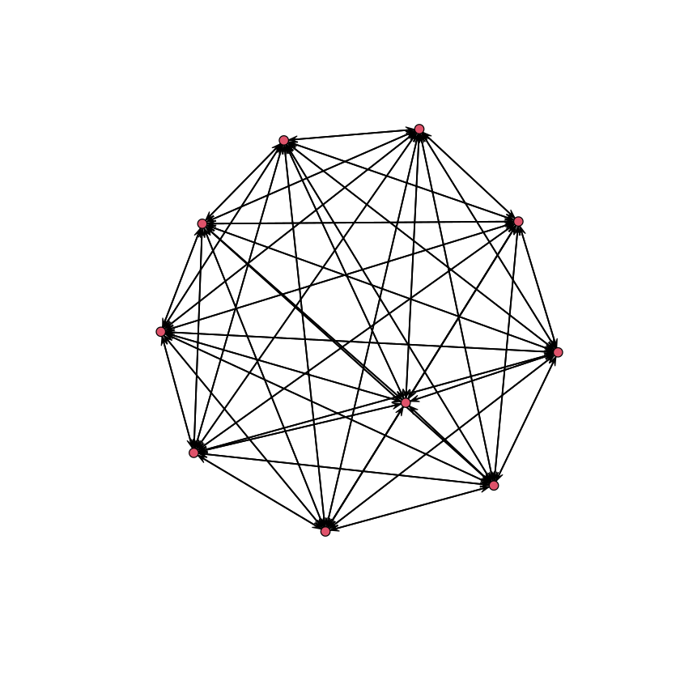

```r
tenclique <- network(matrix(1, ncol = 10, nrow = 10), directed = T)
options(repr.plot.width=7, repr.plot.height=7)
set.seed(210615); plot(tenclique)
```

The `summary` function is very useful when provided with an ERGM model.

> `summary(network ~ ergm-terms)`

```r
summary(tenclique ~ edges + gwesp(0, fixed = T) + gwesp(0.5, fixed = T) + gwesp(1, fixed = T) + gwesp(2, fixed = T) + gwesp(5, fixed = T) + gwesp(10, fixed = T) + ttriple)
```

**edges**

90

**gwesp.fixed.0**

90

**gwesp.fixed.0.5**

148.299667790282

**gwesp.fixed.1**

238.408930794775

**gwesp.fixed.2**

457.230440346895

**gwesp.fixed.5**

703.247272376972

**gwesp.fixed.10**

719.88560256467

**ttriple**

720

#### What happened?

- `gwesp` with decay set to 0 means every edge has "one or more" shared partner - this makes it the same value as the `edge` count term
- as we increase the decay value, it starts to converge toward the `ttriple` term, which is a count of all edgewise shared partners of all edges (i.e. $10\times 9\times 8 = 720$)
- on the one end, you will have an unidentified model (i.e. `edges` and `gwesp` are the same) and on the other end, you will run into degeneracy issues

#### Let's look at a real example using our MIDs network.

- let's increase the decay value to 0.2

```r
m2.b <- ergm(nw ~ edges + nodefactor('dem') + edgecov(joint_dem) + gwdegree(decay = 0.2, fixed = T) + gwesp(decay = 0, fixed = T), control = control.ergm(seed = 210616))
```

```
Starting maximum pseudolikelihood estimation (MPLE):

Evaluating the predictor and response matrix.

Maximizing the pseudolikelihood.

Finished MPLE.

Starting Monte Carlo maximum likelihood estimation (MCMLE):

Iteration 1 of at most 60:

Optimizing with step length 0.3570.

The log-likelihood improved by 1.3288.

Estimating equations are not within tolerance region.

Iteration 2 of at most 60:

Optimizing with step length 1.0000.

The log-likelihood improved by 1.5190.

Estimating equations are not within tolerance region.

Iteration 3 of at most 60:

Optimizing with step length 1.0000.

The log-likelihood improved by 0.4394.

Estimating equations are not within tolerance region.

Iteration 4 of at most 60:

Optimizing with step length 1.0000.

The log-likelihood improved by 0.0368.

```

[output cut: 64 more lines]

```
8
9
10
11
12
13
14
15
16
.

Bridging finished.

This model was fit using MCMC.  To examine model diagnostics and check
for degeneracy, use the mcmc.diagnostics() function.
```

```r
summary(m2.b)
```

```
Call:
ergm(formula = nw ~ edges + nodefactor("dem") + edgecov(joint_dem) +
    gwdegree(decay = 0.2, fixed = T) + gwesp(decay = 0, fixed = T),
    control = control.ergm(seed = 210616))

Monte Carlo Maximum Likelihood Results:

                  Estimate Std. Error MCMC % z value Pr(>|z|)
edges              -4.4797     0.1931      0 -23.195  < 1e-04 ***
nodefactor.dem.1   -0.1274     0.1739      0  -0.732 0.463893
edgecov.joint_dem  -0.2045     0.4263      0  -0.480 0.631492
gwdeg.fixed.0.2    -0.8503     0.2271      0  -3.744 0.000181 ***
gwesp.fixed.0       1.0601     0.1468      0   7.221  < 1e-04 ***
---
Signif. codes:  0 ‘***’ 0.001 ‘**’ 0.01 ‘*’ 0.05 ‘.’ 0.1 ‘ ’ 1

     Null Deviance: 24629  on 17766  degrees of freedom
 Residual Deviance:  1487  on 17761  degrees of freedom

AIC: 1497  BIC: 1536  (Smaller is better. MC Std. Err. = 0.5284)
```

#### Slightly increasing the decay value improved fit and didn't run into degeneracy issues.

## 3.3 Assessing ERGM fit

#### Back to our MIDs model; it seems like our model converged, but we should still check the fit using simulations.

- the ERGM is a generative model, so it can be used to simulate networks that have the same generative features (parameters and configurations)
- simulate a bunch of networks, which lets us check how well our model captures the observed network
- the `gof` function is what we use

```r
m2fit <- gof(m2, control = control.gof.ergm(seed = 210616))
m2fit
```

```
Goodness-of-fit for degree

         obs min  mean max MC p-value
degree0   69  49 68.12  94       0.88
degree1   66  25 44.72  63       0.00
degree2   23  22 34.25  51       0.02
degree3   13  11 21.67  36       0.10
degree4    7   5 11.32  23       0.30
degree5    3   0  5.44  15       0.52
degree6    2   0  2.23   6       1.00
degree7    1   0  0.77   5       0.92
degree8    2   0  0.34   3       0.12
degree9    0   0  0.06   2       1.00
degree10   1   0  0.06   2       0.10
degree11   1   0  0.02   1       0.04
degree18   1   0  0.00   0       0.00

Goodness-of-fit for edgewise shared partner

     obs min  mean max MC p-value
esp0  95  68 95.38 122       0.98
esp1  32   3 38.62  73       0.60
esp2   5   0  2.68  11       0.40
esp3   2   0  0.10   2       0.02

Goodness-of-fit for minimum geodesic distance

      obs   min  mean   max MC p-value
1     134   134   134   134          1
2     419   419   419   419          1
3     658   658   658   658          1
4     765   765   765   765          1
5     737   737   737   737          1
6     489   489   489   489          1
7     359   359   359   359          1
8     203   203   203   203          1
9      90    90    90    90          1
10     28    28    28    28          1
11      6     6     6     6          1
12      1     1     1     1          1
Inf 13877 13877 13877 13877          1

Goodness-of-fit for model statistics

                  obs min   mean max MC p-value
edges             134  88 136.78 199       1.00
nodefactor.dem.1   85  54  85.74 137       0.98
edgecov.joint_dem  12   4  11.72  22       1.00
gwdeg.fixed.0     120  95 120.88 140       0.88
gwesp.fixed.0      39   3  41.40  82       0.94
```

#### What are we looking at?

- we simulated a bunch of networks, and computed some important network statistics
- the output above are summaries of the simulations compared to the observed value
- it's easier to see when we plot them

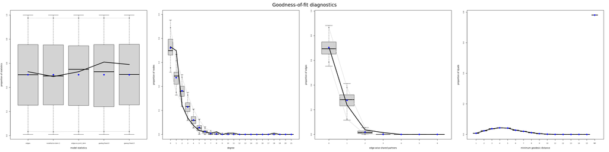

```r
options(repr.plot.width=32, repr.plot.height=8)
par(mfrow = c(1, 4))
plot(m2fit)
```

- black line shows the observed values
- the box and whisker plots show the distributions of the simulated networks
- ideally, we want the observed values to fall in the gray boxes
- we also don't want to "overfit"
- there isn't an exact answer to this task

#### But it helps to compare.

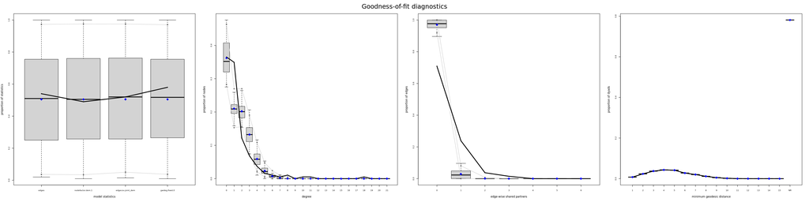

```r
m1fit <- gof(m1, control = control.gof.ergm(seed = 210616))
options(repr.plot.width=32, repr.plot.height=8)
par(mfrow = c(1, 4))
plot(m1fit)
```

## 3.4 Interpreting the ERGM output

#### Let's bring up the model output again.

```r
summary(m2)
```

```
Call:
ergm(formula = nw ~ edges + nodefactor("dem") + edgecov(joint_dem) +
    gwdegree(decay = 0, fixed = T) + gwesp(decay = 0, fixed = T),
    control = control.ergm(seed = 210616))

Monte Carlo Maximum Likelihood Results:

                  Estimate Std. Error MCMC % z value Pr(>|z|)
edges              -4.6965     0.1702      0 -27.594  < 1e-04 ***
nodefactor.dem.1   -0.1392     0.1595      0  -0.873  0.38291
edgecov.joint_dem  -0.2355     0.4113      0  -0.573  0.56692
gwdeg.fixed.0      -0.6418     0.2284      0  -2.810  0.00495 **
gwesp.fixed.0       1.1526     0.1415      0   8.148  < 1e-04 ***
---
Signif. codes:  0 ‘***’ 0.001 ‘**’ 0.01 ‘*’ 0.05 ‘.’ 0.1 ‘ ’ 1

     Null Deviance: 24629  on 17766  degrees of freedom
 Residual Deviance:  1494  on 17761  degrees of freedom

AIC: 1504  BIC: 1543  (Smaller is better. MC Std. Err. = 0.4262)
```

- Coefficients are log odds.

#### At the network level:

- positive coefficient means positive contribution to the network generative process
- for example, positive `gwesp` means triadic closure is a feature of the network
- $exp(\theta_r)$ is the odds of observing a network that is one-unit greater in configuration $r$ (while keeping all other configuration counts constant)

#### At the dyad level:

- how many of each configurations are each edge a part of? (this is the change statistic)
- `nodefactor.dem` will be 0 if two nondemocracies, 1 if mixed regime, and 2 if joint democracies
- `gwesp.fixed.0` will be 1 if the dyad is part of at least one triangle

#### $P(y_{ij} = 1 | Y, \mathbf{\theta}) = logit ^{-1}(\sum^k_{r=1}\theta_r \delta_r^{(ij)}Y)$

> - conditional log odds of a tie given a one unit change in the statistic
> - for the less complicated terms, it becomes the conditional log odds of a tie given that it is part of the local configuration one more time

#### Let's illustrate using a simple example and the same coefficients.

Just a simple three node network with two ties to show tie formation on the empty dyad

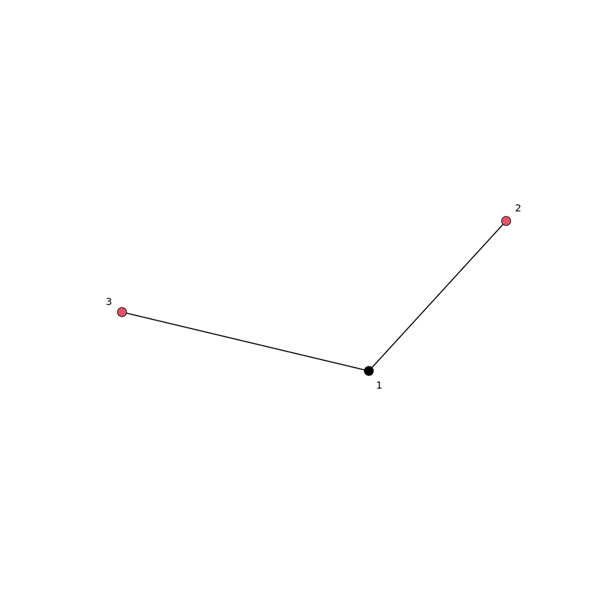

```r
tri <- matrix(c(0, 1, 1,
                1, 0, 0,
                1, 0, 0), byrow = T, ncol = 3)
nw.tri <- network(tri, directed = F)
nw.tri%v%'dem' <- c(0, 1, 1)
jd.tri <- matrix(c(0, 0, 0,
                   0, 0, 1,
                   0, 1, 0), byrow = T, ncol = 3)
options(repr.plot.width=10, repr.plot.height=10)
set.seed(210615); plot(nw.tri, vertex.col = ifelse(nw.tri%v%'dem', 2, 1), displaylabels = T)
```

#### What's the probability of a tie forming on the empty dyad (2,3) if this network has the same generative features of our conflict network?

- we need to see how the addition of the tie will change the network statistics
- the `ergmMPLE` function can help with this, especially with more complicated terms like the geometrically weighted ones

```r
ergmMPLE(nw.tri ~ edges + nodefactor('dem') + edgecov(jd.tri) + gwdegree(decay = 0, fixed = T) + gwesp(decay = 0, fixed = T))$predictor
```

A matrix: 2 × 5 of type dbl

| edges | nodefactor.dem.1 | edgecov.jd.tri | gwdeg.fixed.0 | gwesp.fixed.0 |
| --- | --- | --- | --- | --- |
| 1 | 1 | 0 | 1 | 0 |
| 1 | 2 | 1 | 0 | 3 |

#### There are two types of dyads here:

- (1,2) and (1,3)
- (2,3)

#### Adding an edge on the (2,3) dyad will add...

- 1 edge
- 2 democracies
- 1 joint democracy dyad
- 0 to the `gwdegree.0` term
- 3 to the `gwesp.0` term

#### Why does `gwdegree` not change?

Let's look at the degree distribution:

| nodes with degree: | 0 | 1 | 2 |
| --- | --- | --- | --- |
| w/o (2,3) edge | 0 | 2 | 1 |
| w/ (2,3) edge | 0 | 0 | 3 |

- When the decay value is 0, all node degrees are treated the same
- Adding the (2, 3) edge removes two degree-1 nodes, and adds two degree-2 nodes so `gwdegree.0` does not change

```r
round(coefficients(m2), 2)
```

**edges**

-4.7

**nodefactor.dem.1**

-0.14

**edgecov.joint_dem**

-0.24

**gwdeg.fixed.0**

-0.64

**gwesp.fixed.0**

1.15

#### Calculate the corresponding probability.

```r
plogis(-1.76)
```

0.146790339801382

- generally speaking, it will get confusing to calculate the probability of a tie forming as the networks get more complex and the model terms more nested

#### At the block level:

- Subnetwork-based sampling that can be used to simulate networks from different ERGMs
- Allows for comparison on outcomes of interest when varying certain model terms
- Beyond the scope of what we can do in this tutorial

##### Reference:

Desmarais, BA & Cranmer, SJ. 2012. ["Micro-level interpretations of exponential random graph models with applications to estuary networks."](https://doi.org/10.1111/j.1541-0072.2012.00459.x) *Policy Studies Journal*.

## 3.5 ERGM Settings

#### Let's conclude this section by looking at some settings and useful things to do.

- turn off `eval.loglik` if you are exploring large and complex models
- set a seed to ensure consistency
- increase `MCMC.burnin`, `MCMC.samplesize`, and `MCMC.interval` for higher quality estimates
- use `parallel` to speed up estimation when working with larger models

> See all the settings with `?control.ergm`

```r
m2.c <- ergm(nw ~ edges + nodefactor('dem') + edgecov(joint_dem) + gwdegree(decay = 0, fixed = T) + gwesp(decay = 0, fixed = T),
             eval.loglik = F,
             control = control.ergm(seed = 210615,
                                    MCMC.burnin = 50000,
                                    MCMC.samplesize = 2500,
                                    MCMC.interval = 2500,
                                    parallel = 0))
```

```
Starting maximum pseudolikelihood estimation (MPLE):

Evaluating the predictor and response matrix.

Maximizing the pseudolikelihood.

Finished MPLE.

Starting Monte Carlo maximum likelihood estimation (MCMLE):

Iteration 1 of at most 60:

Optimizing with step length 0.5407.

The log-likelihood improved by 4.6038.

Estimating equations are not within tolerance region.

Iteration 2 of at most 60:

Optimizing with step length 1.0000.

The log-likelihood improved by 1.9610.

Estimating equations are not within tolerance region.

Iteration 3 of at most 60:

Optimizing with step length 1.0000.

The log-likelihood improved by 0.1193.

Estimating equations are not within tolerance region.

Iteration 4 of at most 60:

Optimizing with step length 1.0000.

The log-likelihood improved by 0.0281.

```

[output cut: 37 more lines]

```
Not converged with 99% confidence; increasing sample size.

Iteration 9 of at most 60:

Optimizing with step length 1.0000.

The log-likelihood improved by 0.0029.

Convergence test p-value: < 0.0001.
Converged with 99% confidence.

Finished MCMLE.

This model was fit using MCMC.  To examine model diagnostics and check
for degeneracy, use the mcmc.diagnostics() function.
```

```r
summary(m2.c)
```

```
Log-likelihood was not estimated for this fit. To get deviances, AIC, and/or BIC, use ‘*fit* <-logLik(*fit*, add=TRUE)’ to add it to the object or rerun this function with eval.loglik=TRUE.
```

```
Call:
ergm(formula = nw ~ edges + nodefactor("dem") + edgecov(joint_dem) +
    gwdegree(decay = 0, fixed = T) + gwesp(decay = 0, fixed = T),
    eval.loglik = F, control = control.ergm(seed = 210615, MCMC.burnin = 50000,
        MCMC.samplesize = 2500, MCMC.interval = 2500, parallel = 0))

Monte Carlo Maximum Likelihood Results:

                  Estimate Std. Error MCMC % z value Pr(>|z|)
edges              -4.6948     0.1771      0 -26.510   <1e-04 ***
nodefactor.dem.1   -0.1390     0.1664      0  -0.835   0.4036
edgecov.joint_dem  -0.2336     0.4088      0  -0.572   0.5676
gwdeg.fixed.0      -0.6391     0.2317      0  -2.759   0.0058 **
gwesp.fixed.0       1.1460     0.1468      0   7.809   <1e-04 ***
---
Signif. codes:  0 ‘***’ 0.001 ‘**’ 0.01 ‘*’ 0.05 ‘.’ 0.1 ‘ ’ 1
```

#### We don't get any likelihood-based statistics. We can follow the instructions to add them.

```r
m2.c <- logLik(m2.c, add = T)
```

```
Fitting the dyad-independent submodel...

Bridging between the dyad-independent submodel and the full model...

Setting up bridge sampling...

Using 16 bridges:
1
2
3
4
5
6
7
8
9
10
11
12
13
14
15
16
.

Bridging finished.
```

```r
summary(m2.c)
```

```
Call:
ergm(formula = nw ~ edges + nodefactor("dem") + edgecov(joint_dem) +
    gwdegree(decay = 0, fixed = T) + gwesp(decay = 0, fixed = T),
    eval.loglik = F, control = control.ergm(seed = 210615, MCMC.burnin = 50000,
        MCMC.samplesize = 2500, MCMC.interval = 2500, parallel = 0))

Monte Carlo Maximum Likelihood Results:

                  Estimate Std. Error MCMC % z value Pr(>|z|)
edges              -4.6948     0.1771      0 -26.510   <1e-04 ***
nodefactor.dem.1   -0.1390     0.1664      0  -0.835   0.4036
edgecov.joint_dem  -0.2336     0.4088      0  -0.572   0.5676
gwdeg.fixed.0      -0.6391     0.2317      0  -2.759   0.0058 **
gwesp.fixed.0       1.1460     0.1468      0   7.809   <1e-04 ***
---
Signif. codes:  0 ‘***’ 0.001 ‘**’ 0.01 ‘*’ 0.05 ‘.’ 0.1 ‘ ’ 1

     Null Deviance: 24629  on 17766  degrees of freedom
 Residual Deviance:  1495  on 17761  degrees of freedom

AIC: 1505  BIC: 1544  (Smaller is better. MC Std. Err. = 0.3209)
```

#### Increasing the MCMC samples can improve our estimates.

- we didn't talk about estimation, but the primary way of doing estimation for ERGMs is using MCMC-based methods
- these settings increase the MCMC samples and interval

```
Sample statistics summary:

Iterations = 2803712:6039552
Thinning interval = 2048
Number of chains = 1
Sample size per chain = 1581

1. Empirical mean and standard deviation for each variable,
   plus standard error of the mean:

                    Mean     SD Naive SE Time-series SE
edges             2.8741 19.864   0.4996         0.9986
nodefactor.dem.1  1.4187 15.633   0.3932         0.6645
edgecov.joint_dem 0.1954  4.089   0.1028         0.1352
gwdeg.fixed.0     0.8299  9.662   0.2430         0.3857
gwesp.fixed.0     2.2815 13.649   0.3433         0.7790

2. Quantiles for each variable:

                   2.5% 25% 50% 75% 97.5%
edges             -33.5 -10   2  16    45
nodefactor.dem.1  -27.0 -10   1  12    35
edgecov.joint_dem  -7.0  -3   0   3     9
gwdeg.fixed.0     -20.0  -5   1   8    18
gwesp.fixed.0     -21.5  -7   2  11    31


Are sample statistics significantly different from observed?
                 edges nodefactor.dem.1 edgecov.joint_dem gwdeg.fixed.0
diff.      2.874130297       1.41872233         0.1954459    0.82985452
test stat. 2.878250816       2.13509251         1.4456122    2.15181337
P-val.     0.003998871       0.03275345         0.1482860    0.03141206
           gwesp.fixed.0 Overall (Chi^2)
diff.        2.281467426              NA
test stat.   2.928565083     10.74797367
P-val.       0.003405305      0.05852964

Sample statistics cross-correlations:
                      edges nodefactor.dem.1 edgecov.joint_dem gwdeg.fixed.0
edges             1.0000000        0.7989286         0.4602394     0.8505776
```

[output cut: 30 more lines]

```

Fraction in 1st window = 0.1
Fraction in 2nd window = 0.5

            edges  nodefactor.dem.1 edgecov.joint_dem     gwdeg.fixed.0
           -1.143            -2.195            -2.068            -1.622
    gwesp.fixed.0
           -1.211

Individual P-values (lower = worse):
            edges  nodefactor.dem.1 edgecov.joint_dem     gwdeg.fixed.0
       0.25285063        0.02818016        0.03863393        0.10486900
    gwesp.fixed.0
       0.22606896
Joint P-value (lower = worse):  0.212401 .
```

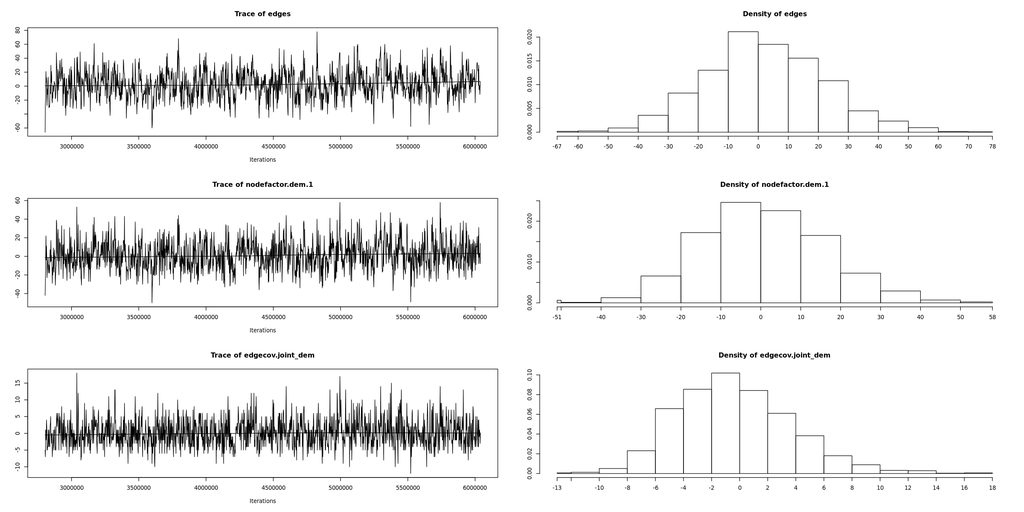

```
MCMC diagnostics shown here are from the last round of simulation, prior to computation of final parameter estimates. Because the final estimates are refinements of those used for this simulation run, these diagnostics may understate model performance. To directly assess the performance of the final…
```

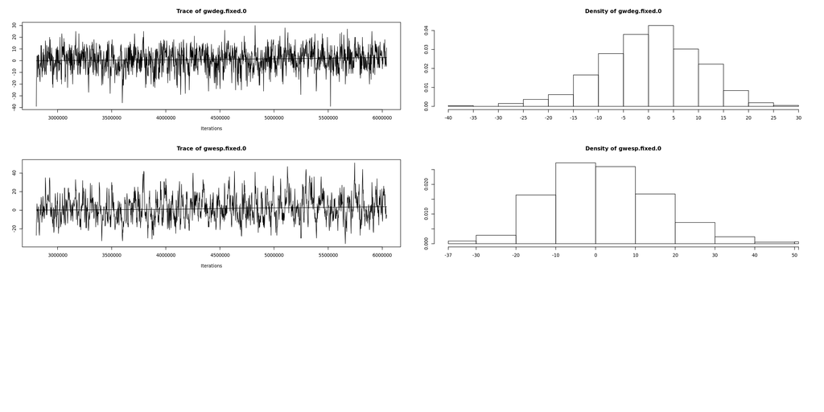

```r
options(repr.plot.width=20, repr.plot.height=10)
mcmc.diagnostics(m2)
```

```
Sample statistics summary:

Iterations = 290784:3852576
Thinning interval = 312
Number of chains = 1
Sample size per chain = 11417

1. Empirical mean and standard deviation for each variable,
   plus standard error of the mean:

                     Mean     SD Naive SE Time-series SE
edges             -0.7379 19.435  0.18189         0.8781
nodefactor.dem.1  -0.2601 15.128  0.14158         0.5677
edgecov.joint_dem -0.1223  4.007  0.03750         0.1165
gwdeg.fixed.0     -0.4866  9.534  0.08922         0.2897
gwesp.fixed.0     -0.2658 13.134  0.12292         0.6814

2. Quantiles for each variable:

                  2.5% 25% 50% 75% 97.5%
edges              -37 -14  -1  12    40
nodefactor.dem.1   -28 -11  -1   9    31
edgecov.joint_dem   -7  -3   0   2     8
gwdeg.fixed.0      -20  -7   0   6    17
gwesp.fixed.0      -22 -10  -1   8    29


Are sample statistics significantly different from observed?
                edges nodefactor.dem.1 edgecov.joint_dem gwdeg.fixed.0
diff.      -0.7379347       -0.2600508        -0.1222738   -0.48664273
test stat. -0.8404137       -0.4580759        -1.0492226   -1.68004510
P-val.      0.4006765        0.6468979         0.2940757    0.09294854
           gwesp.fixed.0 Overall (Chi^2)
diff.         -0.2658317              NA
test stat.    -0.3901499    18.586465455
P-val.         0.6964257     0.002400931

Sample statistics cross-correlations:
                      edges nodefactor.dem.1 edgecov.joint_dem gwdeg.fixed.0
edges             1.0000000        0.8064376         0.4286277     0.8502422
```

[output cut: 30 more lines]

```

Fraction in 1st window = 0.1
Fraction in 2nd window = 0.5

            edges  nodefactor.dem.1 edgecov.joint_dem     gwdeg.fixed.0
          -0.5416           -0.2782            0.7456           -0.4388
    gwesp.fixed.0
          -0.6521

Individual P-values (lower = worse):
            edges  nodefactor.dem.1 edgecov.joint_dem     gwdeg.fixed.0
        0.5880912         0.7808294         0.4559219         0.6608426
    gwesp.fixed.0
        0.5143141
Joint P-value (lower = worse):  0.4488022 .
```

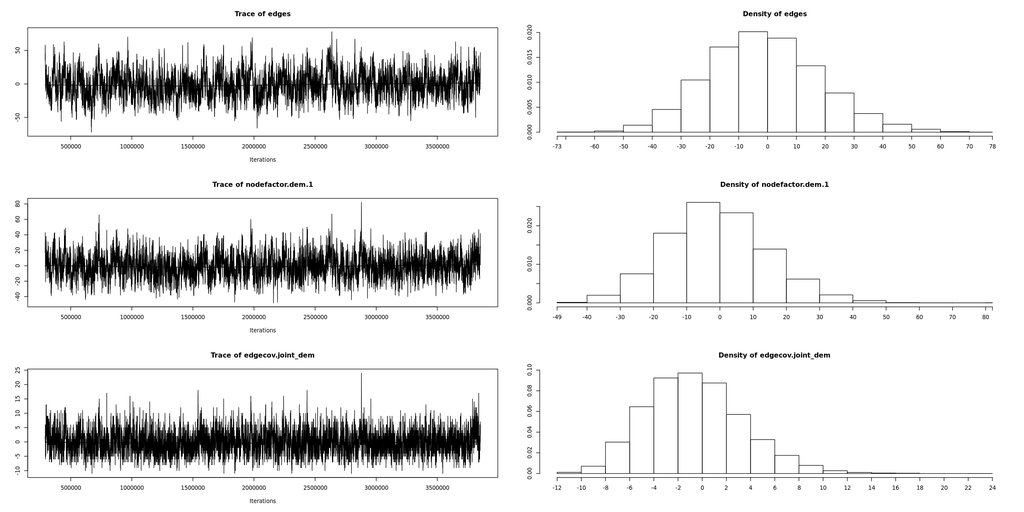

```
MCMC diagnostics shown here are from the last round of simulation, prior to computation of final parameter estimates. Because the final estimates are refinements of those used for this simulation run, these diagnostics may understate model performance. To directly assess the performance of the final…
```

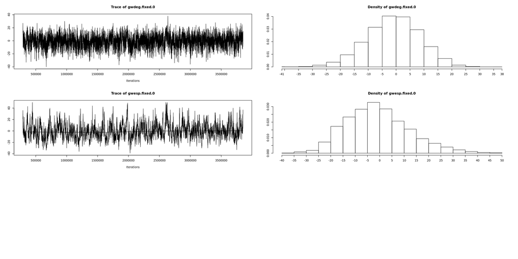

```r
options(repr.plot.width=20, repr.plot.height=10)
mcmc.diagnostics(m2.c)
```

# 4. Resources and References

#### Packages

`statnet` suite of packages have lots of extensions of the ERGM and other network methods

`xergm` package: lots of extensions to the ERGM

`gwdegree` package: helps with understanding gwdegree terms (https://github.com/michaellevy/gwdegree)

#### References

Desmarais, BA & Cranmer, SJ. 2012. ["Micro-level interpretations of exponential random graph models with applications to estuary networks."](https://doi.org/10.1111/j.1541-0072.2012.00459.x) *Policy Studies Journal*.

Hunter, DR et al. 2008. ["ergm: A package to fit, simulate and diagnose exponentiall-family models for networks."](https://doi.org/10.18637/jss.v024.i03) *Journal of Statistical Software*.

Levy, M. 2016. ["gwdegree: Improving interpretation of geometrically-weighted degree estimates in exponential random graph models."](https://doi.org/10.21105/joss.00036) *Journal of Open Source Software*.

Snijders, T et al. 2006. ["New specifications for exponential random graph models."](https://doi.org/10.1111/j.1467-9531.2006.00176.x) *Sociological Methodology*.

# 5. Questions or comments?

#### Please visit the [Github repository](https://github.com/tedhchen/ergmWorkshop) for this notebook.

#### Or email me at ted.hsuanyun.chen@gmail.com.